# CMB710E Final Project - Read Depth Analysis of *Cryptococcus* Hybrids

Kayla Wilhoit

2023-11-05

## Introduction

*Cryptococcus neoformans* is a fungal pathogen that can infect humans, especially immunocompromised individuals. Isolates from clinical samples have revealed that some infections are caused by mixed strains or species of *Cryptococcus,* which can produce diploid hybrids. Genetic sequencing of these hybrids has produced short-read sequences that can be aligned to known reference genomes to determine ancestry.

## Question

Is the hybrid sample aligning equally to both parental reference genomes?

## Data Manipulation

### Looking at the Data

This is a read depth dataset from a clinical sample previously identified to be a diploid hybrid between *C. neoformans* and *C. deneoformans*. The dataset contains the chromosome name from the reference genome, and a measure of read depth within 100bp windows across the reference genome.

```r
depth_data <- select(fread("PMY3391_output.regions.bed.gz"),Lin_Chrom=V1, Start=V2, End=V3, Read_Depth=V4)

glimpse(depth_data)
```

```
## Rows: 381,431
## Columns: 4
## $ Lin_Chrom  <chr> "VNI_CP047902.1", "VNI_CP047902.1", "VNI_CP047902.1", "VNI_…
## $ Start      <int> 0, 100, 200, 300, 400, 500, 600, 700, 800, 900, 1000, 1100,…
## $ End        <int> 100, 200, 300, 400, 500, 600, 700, 800, 900, 1000, 1100, 12…
## $ Read_Depth <dbl> 0.89, 4.59, 12.20, 18.25, 23.33, 21.06, 22.60, 20.18, 19.48…
```

### Cleaning up the Data

The chromosome numbering differs between the two reference genomes, and some chromosome sequences are reverse complemented between the two references. In this code, we correct the chromosome numbering and reverse the start sites for the affected chromosomes.

```r
# Split the information about chromosome and lineage into separate, more readable columns and correct chromosome numbering
names <- as.data.frame(cbind("Lin_Chrom" = unique(depth_data$Lin_Chrom),
               "Chrom" = c(paste("chr", seq(1:14),sep = ""),
                           paste("chr", c(1, 2, 11, 5, 6, 7, 8, 14, 9, 10, 3, 4, 12, 13),sep = "")),
               "Lineage" = str_extract(unique(depth_data$Lin_Chrom), "[^_]+")))

# Join dataset with names
named_dd <- depth_data %>%
  left_join(names, by = "Lin_Chrom")

# Create subset of chromsomes which need to be reverse complemented
filtered <- named_dd %>%
  filter(Lineage == "Cden" & Chrom %in% c("chr1", "chr6",  "chr7",  "chr8",  "chr9",  "chr10", "chr4",  "chr12"))

# Create new Start column with order reversed
rev_start <- filtered %>%
  group_by(Chrom) %>%
  arrange(desc(Start), .by_group = TRUE) %>%
  .[,2]

# Replace original Start column with reversed Start column within the subset of chromosomes
reversed <- filtered %>%
  arrange(Chrom) %>%
  mutate(Start, rev_start)

# Combine the updated subset with the unchanged data
data <- named_dd %>%
  filter(!(Lineage == "Cden" & Chrom %in% c("chr1", "chr6",  "chr7",  "chr8",  "chr9",  "chr10", "chr4",  "chr12"))) %>%
  rbind(reversed)

# Get the mean read depth per chromosome for each lineage
grouped_data <- data %>%
  group_by(Lineage, Chrom) %>%
  summarize(mean = mean(Read_Depth))
```

## Plotting

### Mean Read Depth by Chromosome

Does the mean read depth vary across the chromosomes?

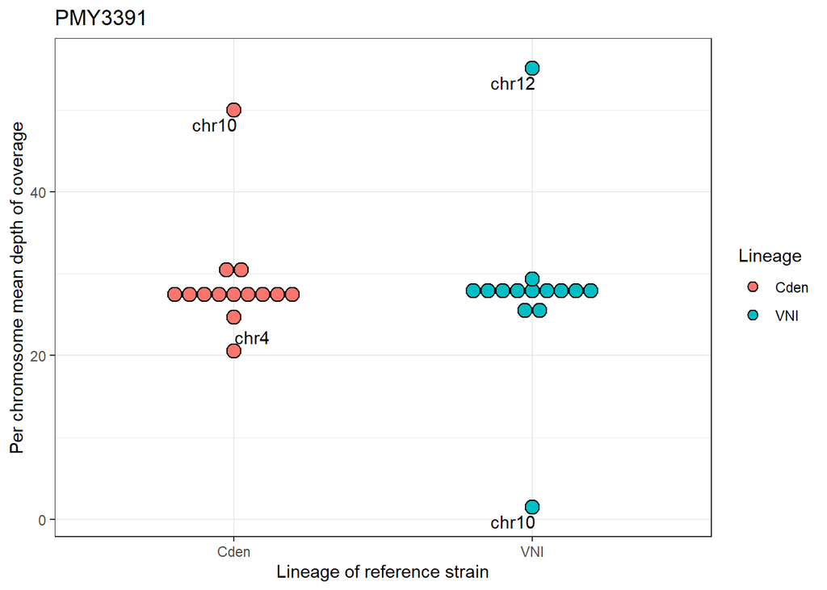

```r
# Create dotplot grouped by lineage with labeled outliers
ggplot(grouped_data, aes(x = Lineage, y = mean, fill = Lineage)) +
  geom_dotplot(binaxis = "y", stackdir = "center") +
  geom_text_repel(aes(label = Chrom), max.overlaps = 2) +
  theme_bw() +
  labs(title = "PMY3391",
       y = "Per chromosome mean depth of coverage",
       x = "Lineage of reference strain")
```

### Read Depth by Position

Is the variation in read depth consistent across the entire chromosome?

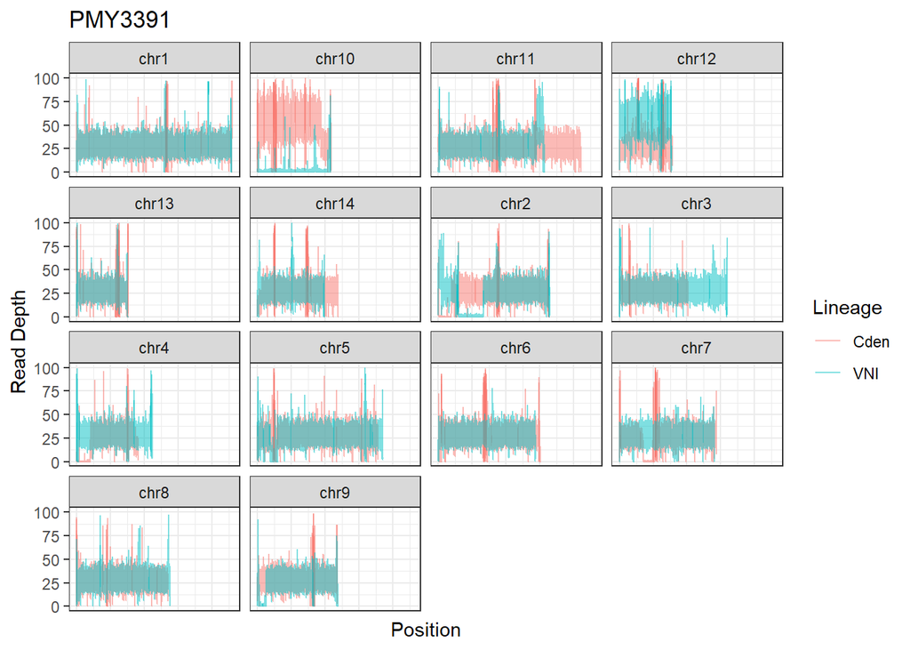

```r
# Create line plot showing read depth for each start position across the chromosome and overlaying both lineages for comparisons across parental species
ggplot(data, aes(Start, Read_Depth, color = Lineage)) +
  geom_line(alpha = 0.50) +
  ylim(0,100) +
  facet_wrap(~`Chrom`) +
  theme_bw() +
  theme(axis.text.x=element_blank(),
        axis.ticks.x=element_blank()) +
  labs(title = "PMY3391",
       y = "Read Depth",
       x = "Position")
```

## Conclusions

It seems that while the hybrid sample is overall an even mix of its parental strains, except for chromosome 10, where the relative read depth suggests that both chromosomes might have come from the *C. deneoformans* parent. Chromosome 12 shows approximately double the expected read depth for one lineage but normal read depth for the other lineage, which could suggest a trisomy event.

### Follow-up Studies

The immediate next step would be to repeat this visualization process on more hybrid samples, including hybrids between different species, to see if there are any patterns in the types of chromosomal abnormalities present.

## Acknowledgements

Thank you to the Magwene lab members for the collection and sequencing of the clinical samples used for this visualization, and to the course instructors for helping with some tricky data manipulation and teaching a great course!